# JEDSAD with MCRT: December Summary

This is a summary of the work I (James) have done on importing JEDSAD MHD wind models into a Monte Carlo radiative transfer code.

After initial testing with a model designed to roughly match Chakravorty et al. (2023), I've been seeing what one needs to do to get winds cold enough to produce optical features. Ideally, we'd be able to some weak blue-shifted absorption in lines like ${\rm H}\alpha$ and ${\rm He~I}~5876~{\rm A}$. For reference, here is a figure from [Munoz-Darias et al. 2019](https://ui.adsabs.harvard.edu/abs/2019ApJ...879L...4M/abstract) showing the absorption feature in the hard state.

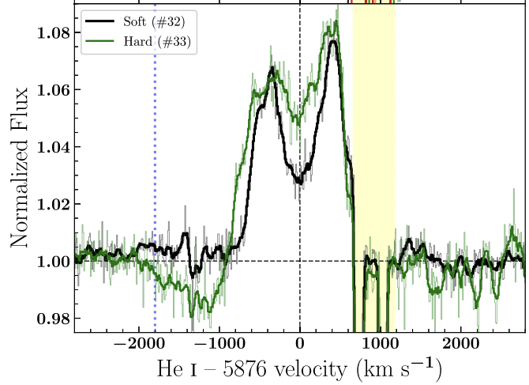

Note that, in [Koljonen et al. (2023)](https://ui.adsabs.harvard.edu/abs/2023MNRAS.521.4190K/abstract) we got a reasonable match to the soft-state emission line spectrum using a parameterised biconical wind model, so we expect getting emission lines out of a wind model to be feasible for reasonable mass-loss rates. Absorption lines is less clear.

## JEDSAD Model and System Parameters

Our JEDSAD solution is solN65. This has the following key parameters (see e.g. Jacquemin-Ide et al.:

- Magnetisation $\mu = 0.0135$
- Mass ejection index $p=0.163$

The file provided me gives the quantities like density, velocity, etc. along a streamline as a function of $y={\rm cotan} \theta= z/r$. I construct a 2D solution in the cylindrical $(r,z)$ or spherical $(R,\theta)$ plane by

- 1- computing the $y$ from $y=z/r$
- 2- interpolating on the value $F(y)$ in the provided column
- 3- a given quantity $A$ like density is then given by a similarity relation: $$A= A(r_g) F(y) \left(\frac{r}{r_g}\right)^\beta$$

where $A(r_g)$ is the value at $r_g$ and the exponent depends on the variable. I've now checked the code that does this pretty carefully and after correcting a few errors I'm pretty confident its doing the 2D grid construction correctly.

The main other fixed parameters of the system are based on MAXI J1820 and are:

- BH Mass, $M_{\rm BH} = 8.5 M_{\odot}$.
- The illuminating SED (shape and normalisation).
- the inner radius of the wind, $R_{\rm min}=10^3~r_g$. Note that I am assuming that the wind does actually extend further in, I'm just truncating it here in the models because I'm guessing the inner wind is very hot and unimportant in the optical (this turns out to be true).

I chose to vary two parameters here:

- the outer wind radius, $R_{\rm max}$
- the normalisation of the mass-loss, set through the parameter $\dot{m}$

The SED is shown in the next panel.

From Pop: *it comes from the best fit of Obs3 of [Marino et al. (2021)](https://ui.adsabs.harvard.edu/abs/2021A%26A...656A..63M/abstract) of Maxi 1820. It corresponds to the observation date of the 24 of March 2018. And this corresponds to Epoch 10 of Munoz-Darias et al. (2019). Epoch 10 does not show absorption lines but they are present 2 days latter and the SED should be rougly the same. So it shoukld be fine.*

This SED has a bolometric luminosity of $2.298 \times 10^{38}~{\rm erg~s}^{-1}$ which correspond to an Eddington fraction of $0.214$.

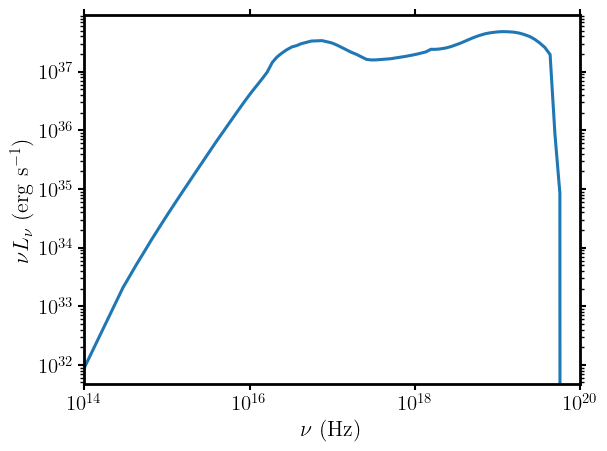

```python
%matplotlib inline
import matplotlib.pyplot as plt
import summary_plot as summary
import warnings
warnings.filterwarnings('ignore')
summary.sed_plot()
```

### How to set $\dot{m}$

For a desired radiated Eddington fraction, assuming the wind runs right down to the ISCO, we have, from the definition of $\dot{m}$ used by Jonathan $$ \dot{m} = \frac{\dot{M}_{\rm acc} c^2}{L_{\rm Edd}} = \frac{\lambda_{\rm Edd}L_{\rm Edd} c^2}{\eta c^2 L_{\rm Edd}} = \frac{\lambda_{\rm Edd}}{\eta} $$ where we take $\eta=1/12$ as the radiative efficiency. For our SED we thus adopt $\dot{m} = 12 \times 0.214 = 2.575$ as the base, steady-state case. However, as Jonathan notes, the inner disc responds slowly to the outer disc, which could have a higher accretion rate and mass-loss rate. There is nothing simultaneous here, and shoud treat the two Mdot as independent (though related) quantities.

This for the moment, I simply try to vary $\dot{m}$ while keeping the SED fixed. I use values of $\dot{m}$ of 2.575, 8.137, and 25.75 (uniform in log space spanning one OOM).

## Runs

Here are the results from five runs with different $\dot{m}$, $R_{\rm max}$.

### Caveats

- All of these models have the "wedge" below the ideal MHD point excised, but clearly this region is likely to be important for emission lines. However, it's unlikely to matter for blue-shifted absorption lines because it's not outflowing and will not cover the continuum source for most sightlines.
- There is a heating prescription in the wind solutions, but it will not match the heating from the model. As such, there is an inconsistency here which could be "iterated" on (i.e. the heating from the RT simulations could be used to inform the prescription in the MHD solution).

### Plot Description

```
Run 1
```

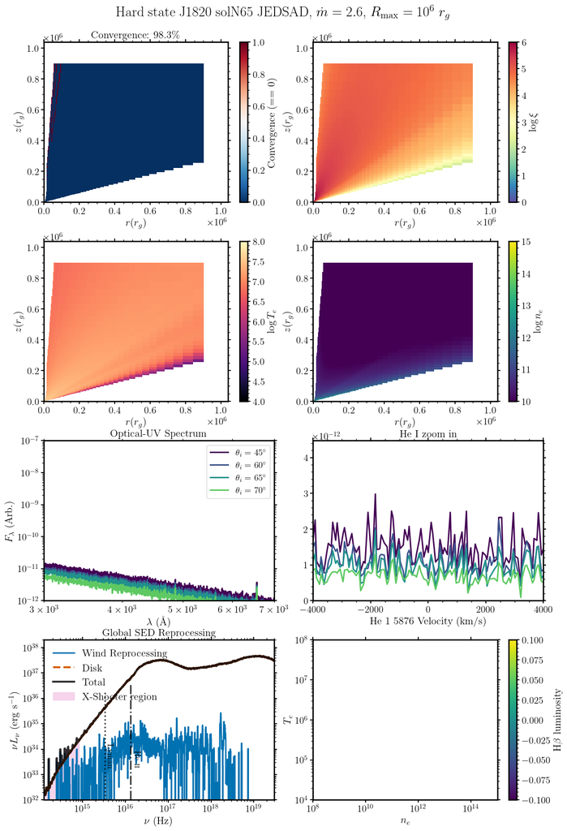

```
Run 2
```

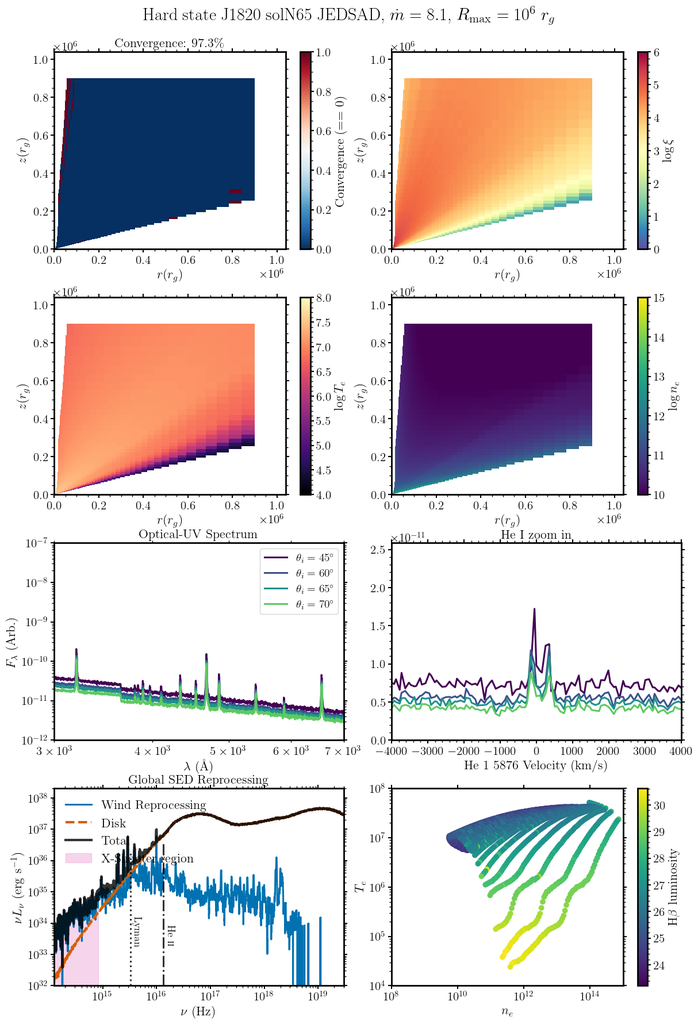

```
Run 3
```

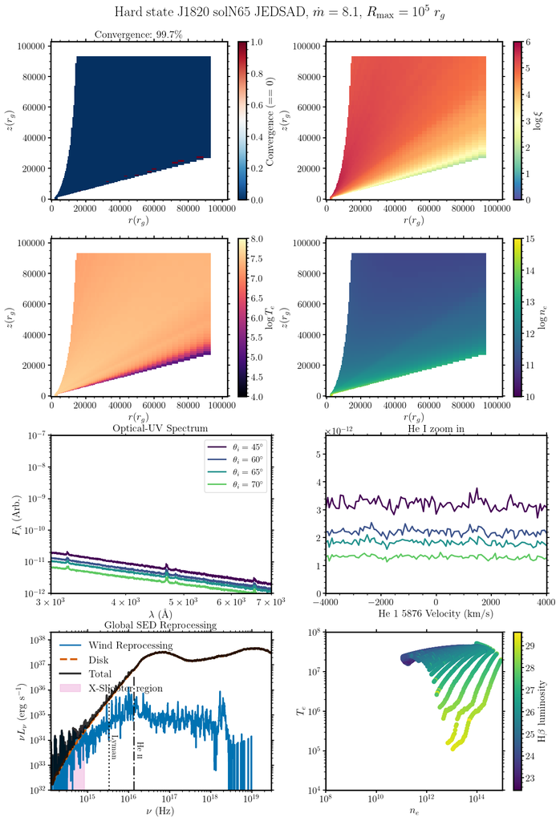

```
Run 4
```

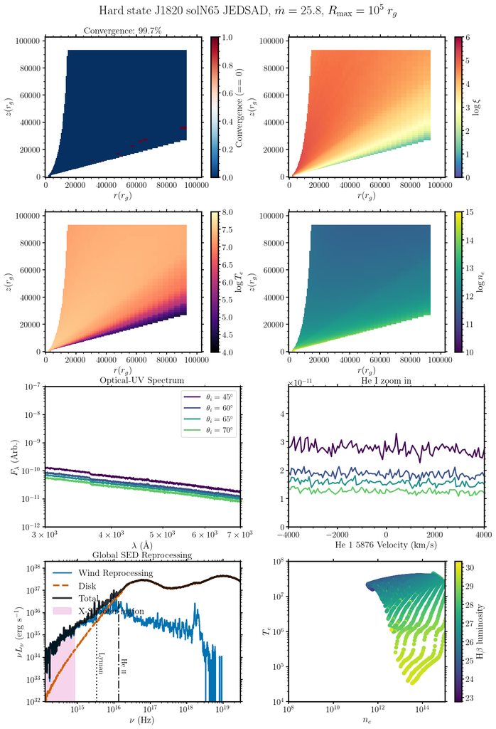

```
Run 5
```

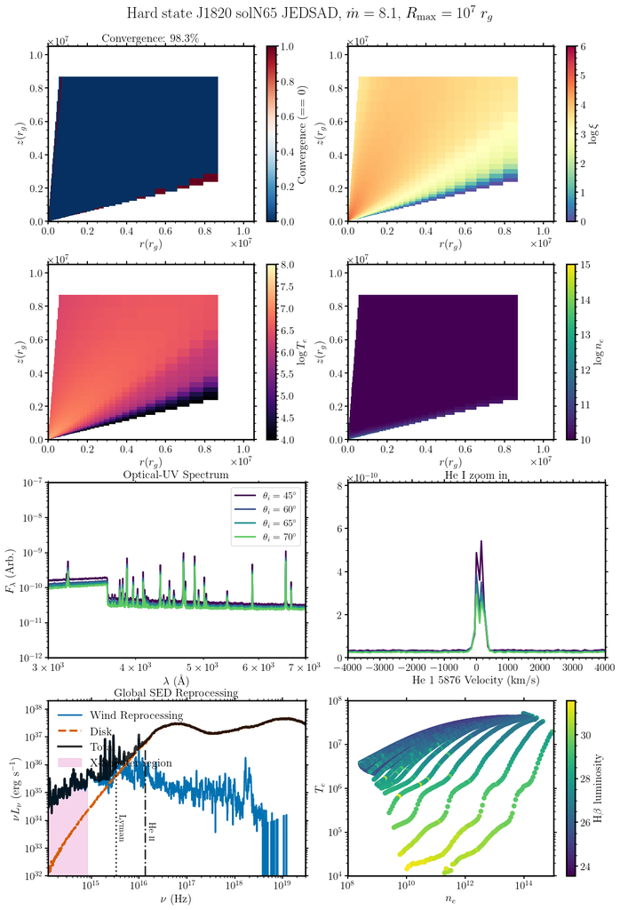

```python
rmaxes = [6,6,5,5,7]
mdot = [2.575, 8.137, 8.137, 25.751, 8.137]
roots = ["hs_jedsad_solN65_rmax6.0_mdot2.575_m8.5",
         "hs_jedsad_solN65_rmax6.0_mdot8.137_mass8.5",
         "hs_jedsad_solN65_rmax5.0_mdot8.137_mass8.5",
         "hs_jedsad_solN65_rmax5.0_mdot25.751_mass8.5",
         "hs_jedsad_solN65_xi0.163_mdot8.137_mass8.5"]
for i,root in enumerate(roots):
        print ("\n\nRun {}".format(i+1))
        summary.make_summary_plot(root, rmaxes[i], mdot[i])
        plt.show()
```

## Summary of these results

Here is a quick summary of some of the main results from the above, in no particular order:

- In massive winds the wind can have a big imprint on the emission line spectrum. Strong double-peaked emission lines are formed near the base of the wind - they are generally a little narrower than observed in 1820 but not far off. The width and strength depends strongly on $R_{\rm max}$ and $\dot{m}$.
- In the dense models, the wind also has a significant reprocessing effect on the continuum and makes the optical-UV slope redder. This is pretty neat and arguably merits a study in and of itself. People typically associated the emission lines with the disk in some way, which is still reasonable in this model, but using the JEDSAD framework gives a physically motivated framework for a "disc atmosphere" or "wind transition region" to study. The results could feasibly change a fair bit if the "wedge" is included.
- The dependence on $R_{\rm max}$ is pretty striking. Moving $R_{\rm max}$ out (to an unrealistically large value for MAXI J1820) means you get much more cool material which can emit recombination lines efficiently. Much of the inner wind is highly ionized.
- The stratified ionization structure is interesting (although expected based on the gradients in ionizing flux and density in the flow), given the multi-phase wind signatures seen in X-ray binaries.
- There are no obvious "wind absorption signatures" in the optical. Presumably this is just because the wind is not optically thick enough in the region where it is significantly outflowing. The obvious next step is to try even higher mass-loss rates, or clumping, or higher values of $p$ (mass ejection indices).